# Análisis de Personas Desaparecidas en México

Tarea 02 — Almacenes y Minería de Datos (2026-2)

Omar Fernando Gramer Muñoz

Kevin Steve Quezada Ordoñez

Jesús Antonio Romero Godoy

Edgar Salgado González

2026-03-27

## El problema

- La desaparición de personas en México es una **crisis humanitaria** documentada por organismos nacionales e internacionales.
- El **Registro Nacional de Personas Desaparecidas y No Localizadas (RNPDNO)** centraliza reportes de instancias estatales y federales.
- Los registros abarcan desde **1961 hasta 2025**, con más de 133 mil reportes acumulados.
- El fenómeno **no es regional**: las 32 entidades federativas tienen casos registrados.

133,887 reportes registrados

32 entidades con casos

64 años de registros (1961–2025)

## Preguntas de investigación

1. ¿En qué **entidades y municipios** se concentra el mayor número de desapariciones?
2. ¿Existen **tendencias temporales** en el fenómeno?
3. ¿Hay diferencias en los patrones según el **sexo o la edad** de las víctimas?
4. ¿Qué **instituciones** reportan más casos y cómo varía por estado?
5. ¿Qué proporción de registros tiene información **confidencial** y cómo afecta al análisis?

## Visión general del dataset

| Propiedad | Valor |
| --- | --- |
| **Archivo** | `data_secretariado.csv` |
| **Registros originales** | 133,887 filas × 11 columnas |
| **Periodo** | 07/05/1961 – 30/09/2025 |
| **Fuente** | RNPDNO (Secretariado Ejecutivo del SNSP) |
| **Unidad de análisis** | Reporte de desaparición (no persona única) |
| **Fuentes de reporte** | 74 instituciones (fiscalías, comisiones, procuradurías) |

```
Columnas originales:
ID_VICTIMA · ORIGEN_REPORTE · FECHA_NACIMIENTO · SEXO
FECHA_DESAPARICION · FECHA_REGISTRO · ESTATUS_VICTIMA
CVE_ENT · ENTIDAD · CVE_MUN · MUNICIPIO
```

## Pipeline de limpieza

**Proceso aplicado (CRISP-DM):**

1. Eliminación de 29 registros inutilizables
2. Tipado de columnas (claves → `Int64`, texto → `string`)
3. Detección del bloque `CONFIDENCIAL` (49,149 registros censurados en las mismas 6 columnas)
4. Parseo y validación de fechas
5. Creación de banderas de integridad temporal

**Dos datasets resultantes:**

```
 Dataset   Filas  Columnas                                          Uso
 General 133,858        16 Análisis descriptivo\n(incluye CONFIDENCIAL)
Temporal  84,738        18     Análisis cronológico\n(sin CONFIDENCIAL)
```

**Note**

Los **49,149 registros** confidenciales se censuran simultáneamente en 6 columnas. No son datos faltantes dispersos sino un bloque estructurado.

## EDA — Distribución por sexo

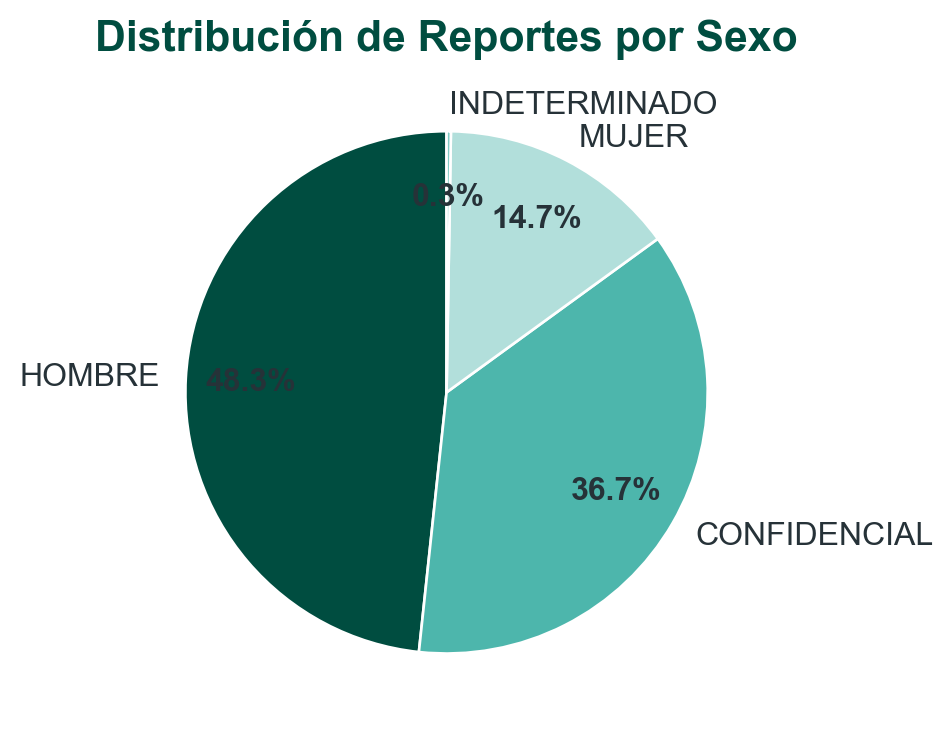

Figure 1: Distribución porcentual de reportes por sexo

## EDA — Entidades con más reportes

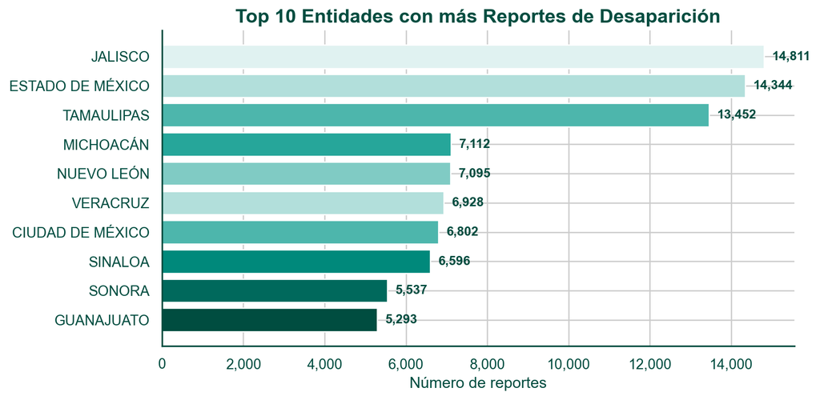

Figure 2: Top 10 entidades federativas por número de reportes

## EDA — Perfil demográfico: edad al desaparecer

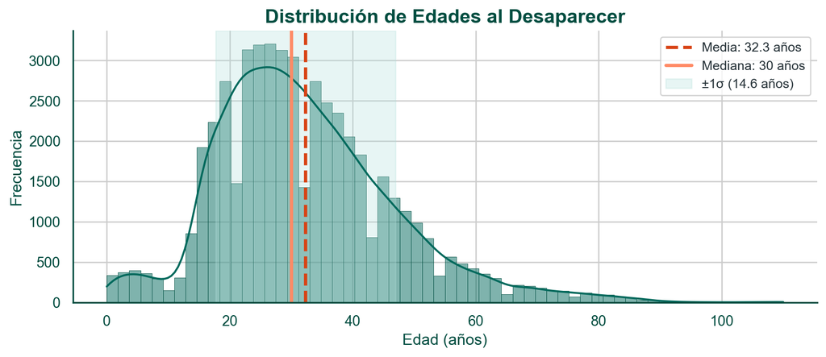

Figure 3: Distribución de edades al momento de la desaparición (dataset temporal)

> **Perfil predominante:** adultos jóvenes de **20 a 40 años**, con media ≈ mediana ≈ 30 años.

## EDA — Tiempo entre desaparición y registro

```
Registros analizados: 72,635
Mediana:  0 días
Media:    16.3 días
Máximo:   18,954 días (52 años)

El 50% se registra el mismo día.
Índice de concentración R = 0.9955
```

**Note**

La mitad de los casos se registran **el mismo día**, pero unos pocos con retraso extremo elevan el promedio drásticamente.

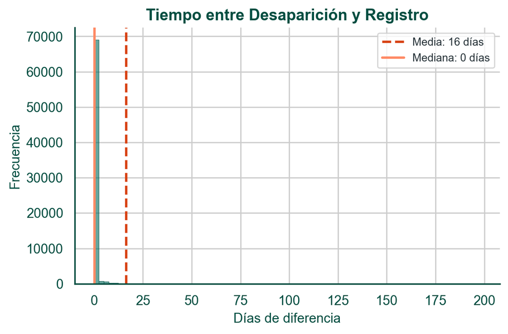

Figure 4: Distribución del tiempo de registro (acotado a 200 días)

## Confidencialidad: un sesgo institucional

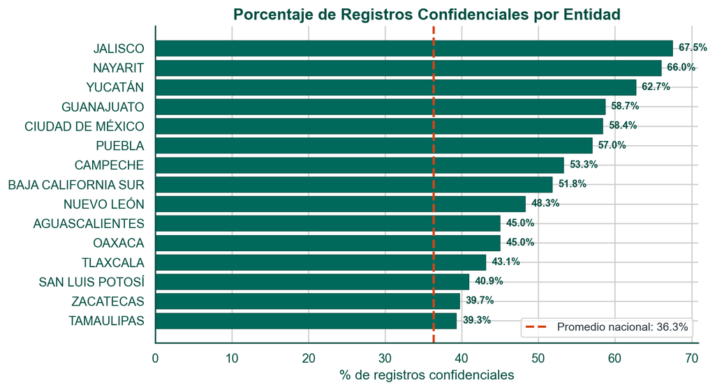

Figure 5: Porcentaje de registros confidenciales por entidad (top 15)

## Principales tendencias identificadas

### Sobre el fenómeno

- **Distribución nacional** pero desigual: Jalisco, Edo. Méx. y Tamaulipas lideran.
- **Perfil predominante:** hombres jóvenes (~30 años) en edad productiva.
- **Registro inmediato** en la mitad de los casos, pero casos extremos distorsionan promedios (R = 0.9955).

### Sobre los datos

- **36.3% de registros confidenciales** — bloque estructurado de 49,149 registros censurados en 6 columnas simultáneas.
- **Desigualdad territorial** en la censura: Jalisco 67.5%, Guanajuato 58.7%, CDMX 58.4%.
- **1,121 anomalías temporales** concentradas en pocas instituciones (65.4% provienen del 15.2% de las fuentes).

**Note**

Las correlaciones **demográfico-temporales** son prácticamente nulas (|r| < 0.01), pero la relación **institución–confidencialidad** es significativa (Jalisco r ≈ 0.18, Chihuahua r ≈ −0.15).

## Implicaciones

1. **Homogeneizar criterios de registro** — La confidencialidad varía drásticamente por entidad; no hay un estándar uniforme.
2. **Focalizar esfuerzos de prevención** — El perfil recurrente (hombres jóvenes en estados con alta actividad delictiva) permite orientar recursos.
3. **Mejorar la calidad de captura** — Las anomalías temporales se concentran en pocas fuentes: son errores sistemáticos corregibles.
4. **El problema es nacional** — Las políticas de atención no pueden limitarse a unas cuantas entidades.

### Gracias

**Almacenes y Minería de Datos — Tarea 02**

Facultad de Ciencias, UNAM · 2026-2

Omar · Steve · Jesús · Edgar